# Data Vis Final Project

Madison Bendele

2024-05-08

```r
library(ggplot2)
library(tidyverse)
library(dplyr)
library(lme4)
library(glmmTMB)
library(MASS)
library(DHARMa)
library(bbmle)
library(gridExtra)
library(car)
library(broom)
library(broom.mixed)
library(emmeans)
```

```r
#phageData is all the phages
phageData <- read.csv("/Users/maddiebendele/Documents/GitHub/DataVisFinal/combo5.csv" )
view(phageData)
# data12 includes the predicted clusters from the MCL using i = 1.2
data12 <- read.csv("/Users/maddiebendele/Documents/GitHub/DataVisFinal/new12.csv" )

# data14 includes the predicted clusters from the MCL  using i = 1.4
data14 <- read.csv("/Users/maddiebendele/Documents/GitHub/DataVisFinal/new14.csv")

# data20 includes the predicted clusters from the MCL  using i = 2.0
data20 <- read.csv("/Users/maddiebendele/Documents/GitHub/DataVisFinal/new2.csv")
# data25 includes the predicted clusters from the MCL using i = 2.5
data25 <- read.csv("/Users/maddiebendele/Documents/GitHub/DataVisFinal/new25.csv")

# data30 includes the predicted clusters from the MCL using i = 3.0
data30 <- read.csv("/Users/maddiebendele/Documents/GitHub/DataVisFinal/inflation30.csv")


#MCL data is all if the purity score and inflation score combined
MCLdata <- read.csv( "/Users/maddiebendele/Documents/GitHub/DataVisFinal/data4statsz2.csv")
```

```r
#There is some data that had no functional category so filtered them out and found the unique phamily names to get a count.
unique_data <- phageData %>% distinct(Phamily, functionCategory)
filtered_data <-unique_data[trimws(unique_data$functionCategory) != "", ]
```

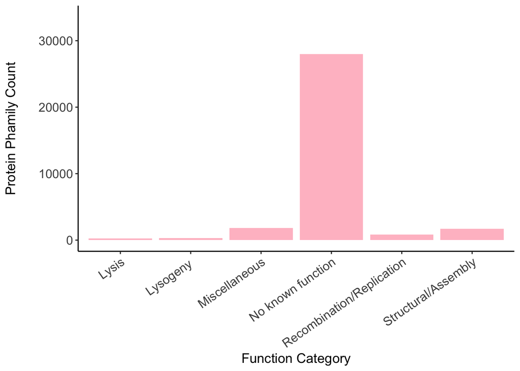

```r
#This code is to fix the functional labels in the bar chart below
label_lookup <- c(
  "lysis" = "Lysis",
  "lysogeny" = "Lysogeny ",
  "misc" = "Miscellaneous",
  "noKnownFunction" = "No known function",
  "recombinationReplication" = "Recombination/Replication",
  "structuralAssembly" = "Structural/Assembly"
)
# Data exploration to see the phamily count per functional category.
ggplot(filtered_data, aes(x = functionCategory)) +
  geom_bar(fill = "pink") +
  labs(x = "Function Category", y = "Protein Phamily Count") +
  theme_classic() +
  theme(axis.text.x = element_text(angle = 35, hjust = 1, size = 12),  # Adjust the font size
        axis.title.y = element_text(margin = margin(t = 15, r = 20), size = 13),
        axis.text.y = element_text(size = 12),
        axis.title.x = element_text(size = 13)) +  # Adjust the font size of x-axis title
  ylim(0, max(table(filtered_data$functionCategory)) * 1.2) +  # Adjust the multiplier as needed
  scale_x_discrete(labels = label_lookup)
```

```r
library(dplyr)
library(ggplot2)

# Finding the count of genes for each phage
gene_counts <- phageData %>%
  group_by(phagename) %>%
  summarize(gene_count = n())

# View the result
print(gene_counts)
```

```
## # A tibble: 4,915 × 2
##    phagename gene_count
##    <chr>          <int>
##  1 20ES              96
##  2 244              142
##  3 32HC              86
##  4 39HC             100
##  5 40AC              89
##  6 40BC             100
##  7 8UZL              69
##  8 A3Wally          350
##  9 A6                85
## 10 ABCat            143
## # ℹ 4,905 more rows
```

```r
# Density plot for the count of genes
ggplot(gene_counts, aes(x = gene_count)) +
  geom_density(fill = "#4B0092", alpha = 0.6) +
  labs(x = "Number of genes in phage genomes", y = "Density") +
  theme_classic() +
  theme(axis.text = element_text(size = 12),
        axis.title = element_text(size = 13),
        axis.title.y = element_text(margin = margin(r = 20))) +
  geom_vline(aes(xintercept = mean(gene_count)), color = "#1AFF1A", linetype = "dashed", size = 1) +
  annotate("text", x = mean(gene_counts$gene_count), y = max(density(gene_counts$gene_count)$y) * 0.8,
           label = paste0("Average: ", round(mean(gene_counts$gene_count))), color = "#4B0092", hjust = -0.1)
```

[figure not shown]

```r
#Filtering out the not needed data for each id value predicted by the MCL

filtered_data12 <- data12 %>%
  dplyr::select(Phamily, id, functionCategory)

#A way to see how heterogeneous the function categories are for an id number
result12 <- filtered_data12 %>%
  group_by(id) %>%
  summarise(unique_functions = n_distinct(functionCategory))


filterdata14 <- data14 %>% dplyr::select(Phamily, id, functionCategory)

result14 <- filterdata14 %>%
  group_by(id) %>%
  summarise(unique_functions = n_distinct(functionCategory))


filterdata20 <- data20 %>% dplyr::select(Phamily, id, functionCategory)

result20 <- filterdata20 %>%
  group_by(id) %>%
  summarise(unique_functions = n_distinct(functionCategory))

view(result20)

filterdata25 <- data25 %>% dplyr::select(Phamily, id, functionCategory)
#Used to get number of clusters predicted by MCL
result25 <- filterdata25 %>%
  group_by(id) %>%
  summarise(unique_functions = n_distinct(id))

view(result25)

filterdata30 <- data30 %>% dplyr::select(Phamily, id, functionCategory)
view(filterdata30)
#Used to get number of clusters predicted by MCL


result30 <- filterdata30 %>%
  group_by(id) %>%
  summarise(unique_functions = n_distinct(id))

#For each inflation value filtered out the ones labeled noKnownFunction and misc
#since the function is ambigous

filtereddata12 <- filtered_data12 %>%
  filter(!(functionCategory %in% c("noKnownFunction", "misc")))

filtered_data14 <- filterdata14 %>%
  filter(!(functionCategory %in% c("noKnownFunction", "misc")))


filtered_data20 <- filterdata20 %>%
  filter(!(functionCategory %in% c("noKnownFunction", "misc")))

filtered_data25 <- filterdata25 %>%
  filter(!(functionCategory %in% c("noKnownFunction", "misc")))

filtered_data30 <- filterdata30 %>%
  filter(!(functionCategory %in% c("noKnownFunction", "misc")))
```

```r
purity_scores122 <- filtered_data12 %>%
  group_by(id) %>%
  summarise(
    total_proteins = n(),
  # For each id find which function category has the most proteins
    majority_class = names(which.max(table(functionCategory))),
  #Count the number of proteins that are within the majority functional category
    majority_class_count = max(table(functionCategory)),
  #to get the purity score divide the majority category by the total amount of proteins in a id
    purity_score = majority_class_count / total_proteins
  ) %>%
  #filtered out the instances with only one total protein since that skews the homogeneity of the data
  filter(total_proteins > 1)

#Saved the purity score as a csv
purity1222 <- "/Users/maddiebendele/Desktop/purity1222.csv"
write.csv(purity_scores122, file = purity1222, row.names = FALSE)

#the following code is the same code as above but with the different inflation values

purity_scores144 <- filtered_data14 %>%
  group_by(id) %>%
  summarise(
    total_proteins = n(),
    majority_class = names(which.max(table(functionCategory))),
    majority_class_count = max(table(functionCategory)),
    purity_score = majority_class_count / total_proteins
  ) %>%
  filter(total_proteins > 1)

filterd144 <- "/Users/maddiebendele/Desktop/filterd144.csv"
write.csv(purity_scores144, file = filterd144, row.names = FALSE)


purity_scores200 <- filtered_data20 %>%
  group_by(id) %>%
  summarise(
    total_proteins = n(),
    majority_class = names(which.max(table(functionCategory))),
    majority_class_count = max(table(functionCategory)),
    purity_score = majority_class_count / total_proteins
  ) %>%
  filter(total_proteins > 1)

filterd200 <- "/Users/maddiebendele/Desktop/filterd200.csv"
write.csv(purity_scores200 , file = filterd200, row.names = FALSE)


purity_scores255 <- filtered_data25 %>%
  group_by(id) %>%
  summarise(
    total_proteins = n(),
    majority_class = names(which.max(table(functionCategory))),
    majority_class_count = max(table(functionCategory)),
    purity_score = majority_class_count / total_proteins
  ) %>%
  filter(total_proteins > 1)

filterd255 <- "/Users/maddiebendele/Desktop/filterd255.csv"
write.csv(purity_scores255, file = filterd255, row.names = FALSE)



purity_scores300 <- filtered_data30 %>%
  group_by(id) %>%
  summarise(
    total_proteins = n(),
    majority_class = names(which.max(table(functionCategory))),
    majority_class_count = max(table(functionCategory)),
    purity_score = majority_class_count / total_proteins
  ) %>%
  filter(total_proteins > 1)

filterd300 <- "/Users/maddiebendele/Desktop/filterd300.csv"
write.csv(purity_scores300, file = filterd300, row.names = FALSE)



purity_scores33 <- filtered_data12 %>%
  group_by(id) %>%
  summarise(
    total_proteins = n(),
    majority_class = names(which.max(table(functionCategory))),
    majority_class_count = max(table(functionCategory)),
    purity_score = majority_class_count / total_proteins
  ) %>%
  filter(total_proteins > 1)
```

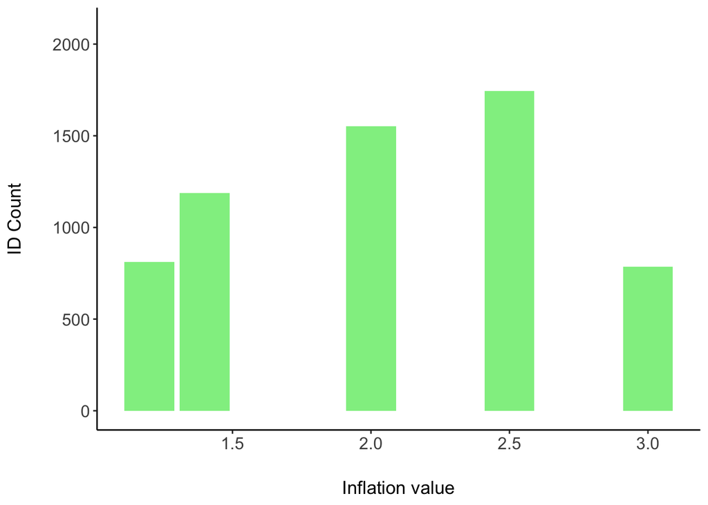

```r
#The count of predicted clusters by different inflation values
bar_chart <- MCLdata %>%
  group_by(infilation) %>% summarise(total_id = n())

#Bar chart of the number of clusters per inflation value
ggplot(bar_chart, aes(x = infilation, y = total_id)) +
  geom_bar(stat = "identity", fill = "lightgreen") +
  labs(x = "Inflation value", y = "ID Count") +
  theme_classic() +
  theme(
    axis.text = element_text(size = 12),  # Set font size for axis numbers
    axis.title = element_text(size = 13),  # Set font size for axis labels
    axis.title.y = element_text(margin = margin(r = 20)),  # Move y-axis label away from numbers
    axis.title.x = element_text(margin = margin(t = 20))  # Move x-axis label away from values
  ) +
  ylim(0, max(bar_chart$total_id) * 1.2)  # Set y-
```

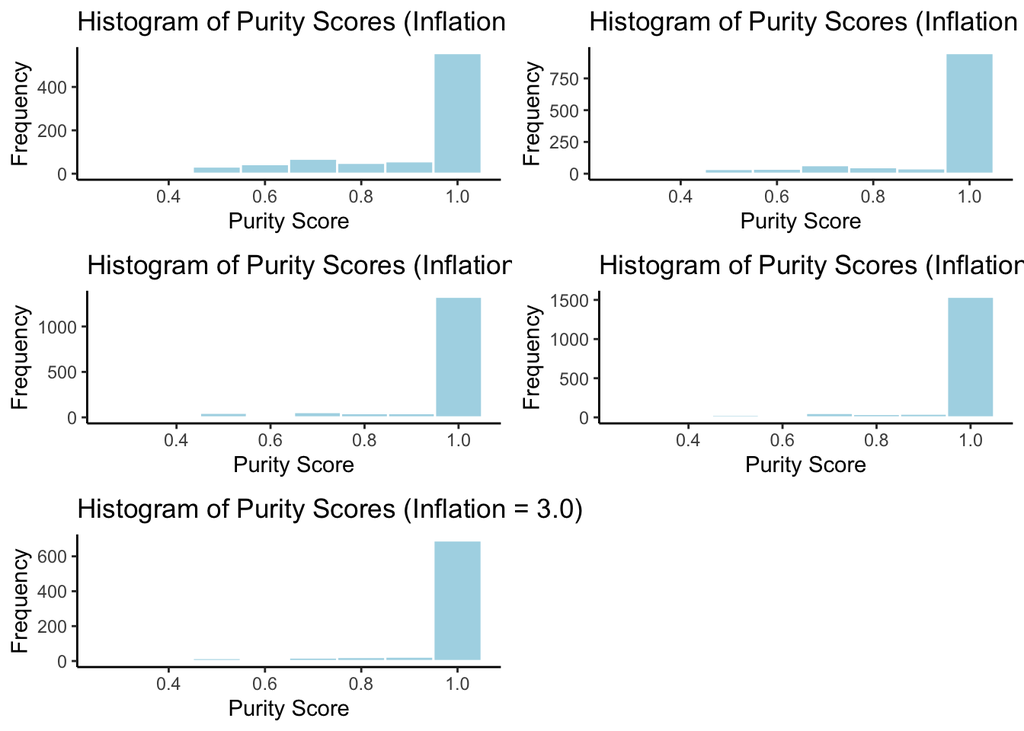

```r
#Filter the data to pull out each inflation value
purity12 <- MCLdata%>%
  filter(infilation == 1.2)

purity14 <- MCLdata%>%
  filter(infilation == 1.4)

purity20 <- MCLdata%>%
  filter(infilation == 2)

purity25 <- MCLdata%>%
  filter(infilation == 2.5)

purity30 <- MCLdata%>%
  filter(infilation == 3)
#histogram of the purity score for each inflation value

hist12 <- ggplot(data = purity12, aes(x = purity_score)) +
  geom_histogram(binwidth = 0.1, fill = "lightblue", color = "white") +
  labs(title = "Histogram of Purity Scores (Inflation = 1.2)",
       x = "Purity Score",
       y = "Frequency") +
 theme_classic()

hist14 <- ggplot(data = purity14, aes(x = purity_score)) +
  geom_histogram(binwidth = 0.1, fill = "lightblue", color = "white") +
  labs(title = "Histogram of Purity Scores (Inflation = 1.4)",
       x = "Purity Score",
       y = "Frequency") +
 theme_classic()

hist20 <- ggplot(data = purity20, aes(x = purity_score)) +
  geom_histogram(binwidth = 0.1, fill = "lightblue", color = "white") +
  labs(title = "Histogram of Purity Scores (Inflation = 2.0)",
       x = "Purity Score",
       y = "Frequency") +
  theme_classic()

hist25 <- ggplot(data = purity25, aes(x = purity_score)) +
  geom_histogram(binwidth = 0.1, fill = "lightblue", color = "white") +
  labs(title = "Histogram of Purity Scores (Inflation = 2.5)",
       x = "Purity Score",
       y = "Frequency") +
  theme_classic()

hist30 <- ggplot(data = purity30, aes(x = (purity_score))) +
  geom_histogram(binwidth = 0.1, fill = "lightblue", color = "white") +
  labs(title = "Histogram of Purity Scores (Inflation = 3.0)",
       x = "Purity Score",
       y = "Frequency") +
  theme_classic()
#plot the figures to see them all at once
  arranged_plots <- grid.arrange(hist12, hist14, hist20, hist25, hist30, ncol = 2)
```

```r
ggsave("purity_histograms.png", arranged_plots, width = 10, height = 8, dpi = 300)
```

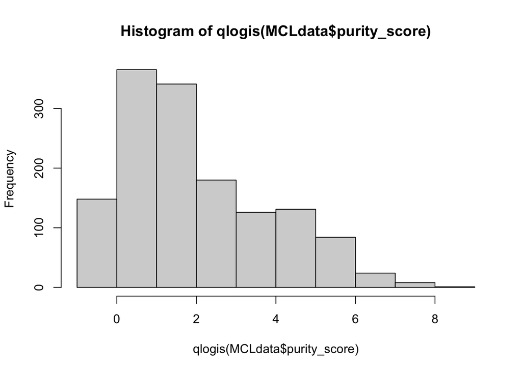

```r
#The Poisson model
modPos <- glm(majority_class_count ~ infilation + I(infilation^2)  + offset(log(total_proteins)),   family = poisson, data = MCLdata)

#The Beta model
modelBeta <- glmmTMB((purity_score-0.00000000001) ~ infilation + I(infilation^2) ,
                 family = beta_family(link = "logit"),
                 data = MCLdata)

#The Gaussian model
modGaus1 <- glm((qlogis(purity_score-0.00000000001)) ~ infilation+I(infilation^2), data = MCLdata, family =  gaussian())
# Seeing that the qlogis improves the distribution of the histogram
hist(qlogis(MCLdata$purity_score))
```

```r
#Checking the AIC score to see the model
ICtab(modPos, modGaus1, modelBeta, base = T, weights = T)
```

```
##           AIC       dAIC      df weight
## modelBeta -194641.9       0.0 4  1
## modPos      33835.9  228477.8 3  <0.001
## modGaus1    44922.9  239564.8 4  <0.001
```

```r
#Anova for each model
Anova(modPos)
```

```
## Analysis of Deviance Table (Type II tests)
##
## Response: majority_class_count
##                 LR Chisq Df Pr(>Chisq)
## infilation        41.221  1  1.359e-10 ***
## I(infilation^2)   21.877  1  2.907e-06 ***
## ---
## Signif. codes:  0 '***' 0.001 '**' 0.01 '*' 0.05 '.' 0.1 ' ' 1
```

```r
Anova(modelBeta)
```

```
## Analysis of Deviance Table (Type II Wald chisquare tests)
##
## Response: (purity_score - 1e-11)
##                  Chisq Df Pr(>Chisq)
## infilation      17.590  1   2.74e-05 ***
## I(infilation^2) 11.673  1  0.0006343 ***
## ---
## Signif. codes:  0 '***' 0.001 '**' 0.01 '*' 0.05 '.' 0.1 ' ' 1
```

```r
Anova(modGaus1)
```

```
## Analysis of Deviance Table (Type II tests)
##
## Response: (qlogis(purity_score - 1e-11))
##                 LR Chisq Df Pr(>Chisq)
## infilation        62.761  1  2.334e-15 ***
## I(infilation^2)   40.724  1  1.753e-10 ***
## ---
## Signif. codes:  0 '***' 0.001 '**' 0.01 '*' 0.05 '.' 0.1 ' ' 1
```

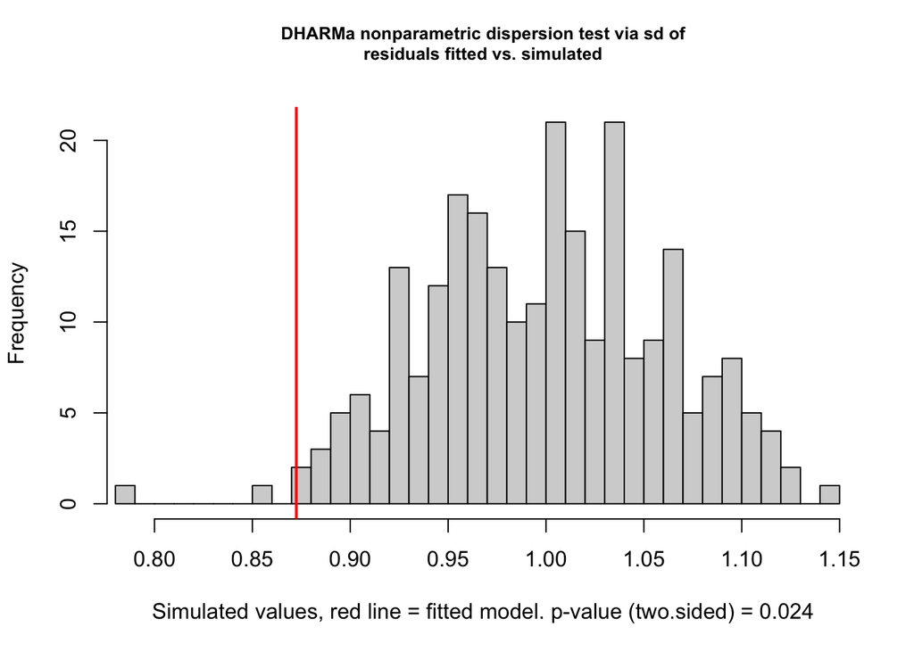

```
##
##  DHARMa nonparametric dispersion test via sd of residuals fitted vs.
##  simulated
##
## data:  simulationOutput
## dispersion = 0.87317, p-value = 0.024
## alternative hypothesis: two.sided
```

```r
#looking at dispersion for each model
testDispersion(modelBeta)
```

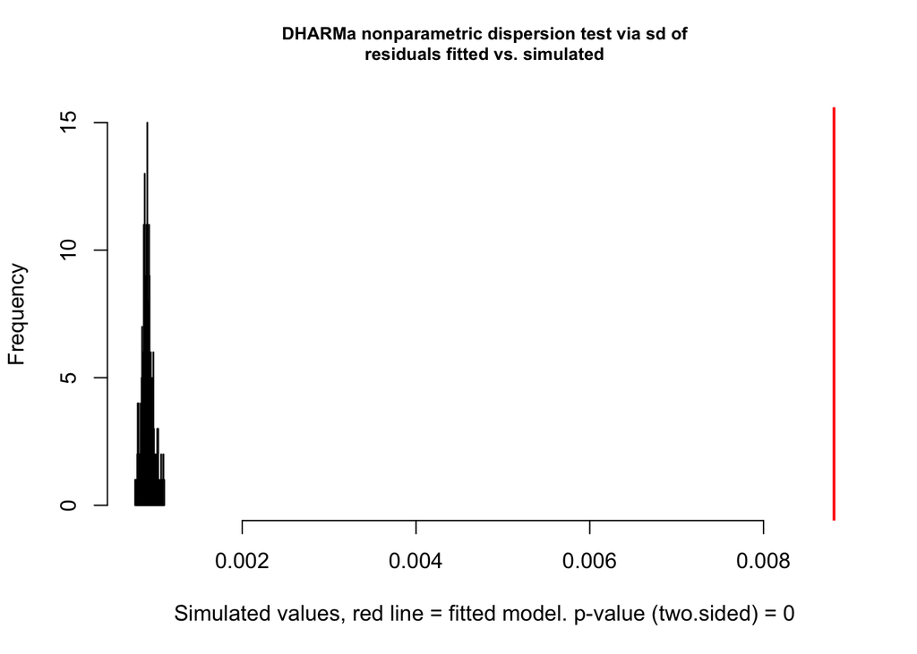

```
##
##  DHARMa nonparametric dispersion test via sd of residuals fitted vs.
##  simulated
##
## data:  simulationOutput
## dispersion = 9.6787, p-value < 2.2e-16
## alternative hypothesis: two.sided
```

```r
testDispersion(modPos)
```

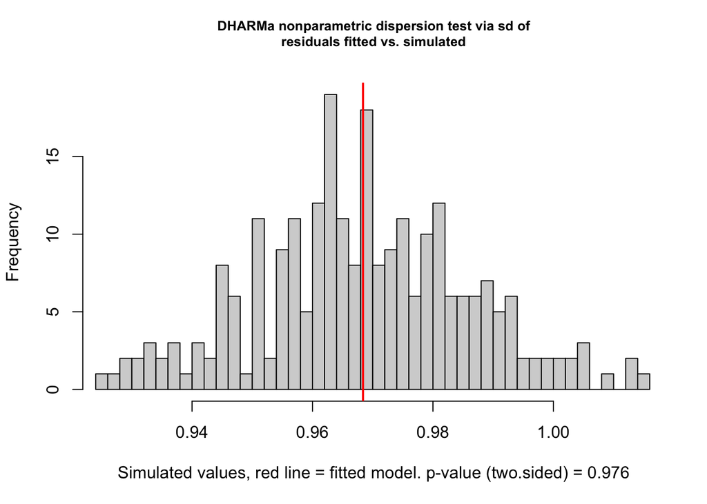

```
##
##  DHARMa nonparametric dispersion test via sd of residuals fitted vs.
##  simulated
##
## data:  simulationOutput
## dispersion = 1.0001, p-value = 0.976
## alternative hypothesis: two.sided
```

```r
testDispersion(modGaus1)
```

```r
#DHARMa package for the residuals
simulateResiduals(fittedModel = modelBeta)
```

```
## Object of Class DHARMa with simulated residuals based on 250 simulations with refit = FALSE . See ?DHARMa::simulateResiduals for help.
##
## Scaled residual values: 0.06 0.7 0.676 0.056 0.676 0.684 0.012 0.692 0.74 0.2 0.044 0.144 0.708 0.044 0.692 0.736 0.724 0.736 0.036 0.712 ...
```

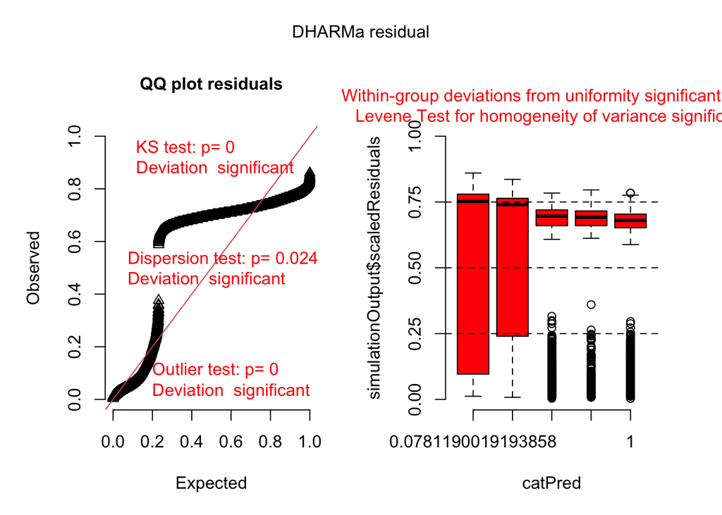

```r
simulationOutputB <-simulateResiduals(fittedModel = modelBeta)
simulationOutputP<-simulateResiduals(fittedModel = modPos)
simulationOutputG<-simulateResiduals(fittedModel = modGaus1)

#Visualize the residuals
plotB <- plot(simulationOutputB)
```

```
## DHARMa:testOutliers with type = binomial may have inflated Type I error rates for integer-valued distributions. To get a more exact result, it is recommended to re-run testOutliers with type = 'bootstrap'. See ?testOutliers for details
```

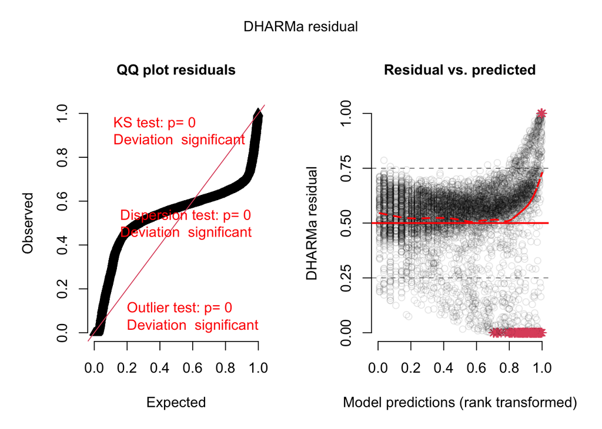

```r
plotP <- plot(simulationOutputP)
```

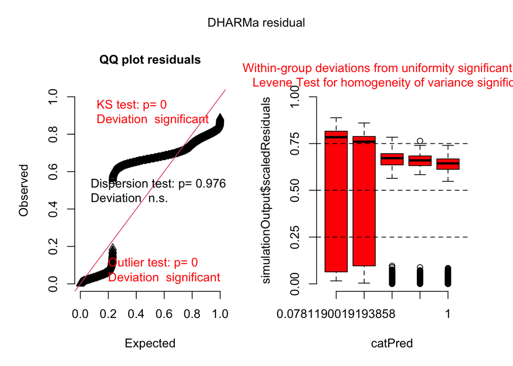

```r
plotG <- plot(simulationOutputG)
```

```r
#Running the models but with inflation as category
# Poisson with categorical
modPosCat <- glm(majority_class_count ~ as.factor(infilation) + offset(log(total_proteins)),   family = poisson, data = MCLdata)
# Beta with categorical
modelBetaCat <- glmmTMB((purity_score-0.00000000001) ~ as.factor(infilation),
                 family = beta_family(link = "logit"),
                 data = MCLdata)
# Gaussian with categorical
modGausCat <- glm((qlogis(purity_score-0.00000000001)) ~ as.factor(infilation), data = MCLdata, family =  gaussian())
#The AIC score for each model
ICtab(modPosCat,modelBetaCat,modGausCat)
```

```
##              dAIC     df
## modelBetaCat      0.0 6
## modPosCat    228457.1 5
## modGausCat   239553.4 6
```

```r
#Anovas for each model
Anova(modelBetaCat)
```

```
## Analysis of Deviance Table (Type II Wald chisquare tests)
##
## Response: (purity_score - 1e-11)
##                        Chisq Df Pr(>Chisq)
## as.factor(infilation) 60.444  4   2.34e-12 ***
## ---
## Signif. codes:  0 '***' 0.001 '**' 0.01 '*' 0.05 '.' 0.1 ' ' 1
```

```r
Anova(modPosCat)
```

```
## Analysis of Deviance Table (Type II tests)
##
## Response: majority_class_count
##                       LR Chisq Df Pr(>Chisq)
## as.factor(infilation)   265.79  4  < 2.2e-16 ***
## ---
## Signif. codes:  0 '***' 0.001 '**' 0.01 '*' 0.05 '.' 0.1 ' ' 1
```

```r
Anova(modGausCat)
```

```
## Analysis of Deviance Table (Type II tests)
##
## Response: (qlogis(purity_score - 1e-11))
##                       LR Chisq Df Pr(>Chisq)
## as.factor(infilation)   218.83  4  < 2.2e-16 ***
## ---
## Signif. codes:  0 '***' 0.001 '**' 0.01 '*' 0.05 '.' 0.1 ' ' 1
```

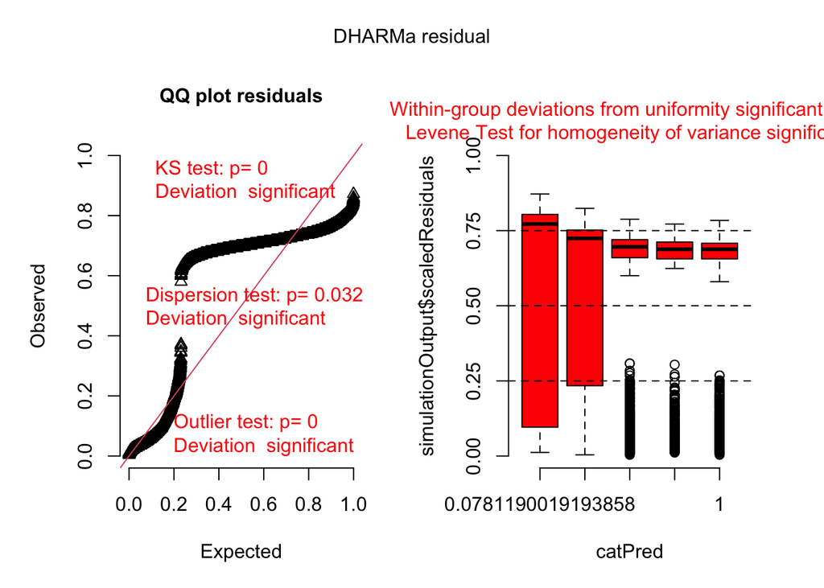

```r
simulationOutputB1 <-simulateResiduals(fittedModel = modelBetaCat)
simulationOutputP1<-simulateResiduals(fittedModel = modPosCat)
simulationOutputG1<-simulateResiduals(fittedModel = modGausCat )

#Visualize the residuals
plotB <- plot(simulationOutputB1)
```

```
## DHARMa:testOutliers with type = binomial may have inflated Type I error rates for integer-valued distributions. To get a more exact result, it is recommended to re-run testOutliers with type = 'bootstrap'. See ?testOutliers for details
```

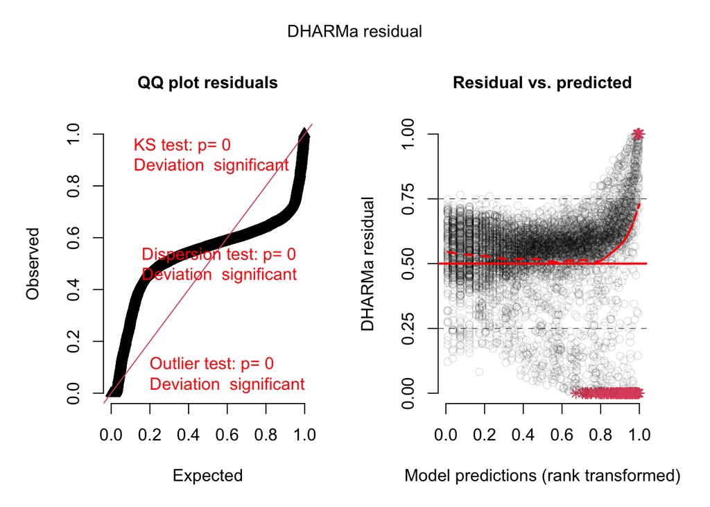

```r
plotP <- plot(simulationOutputP1)
```

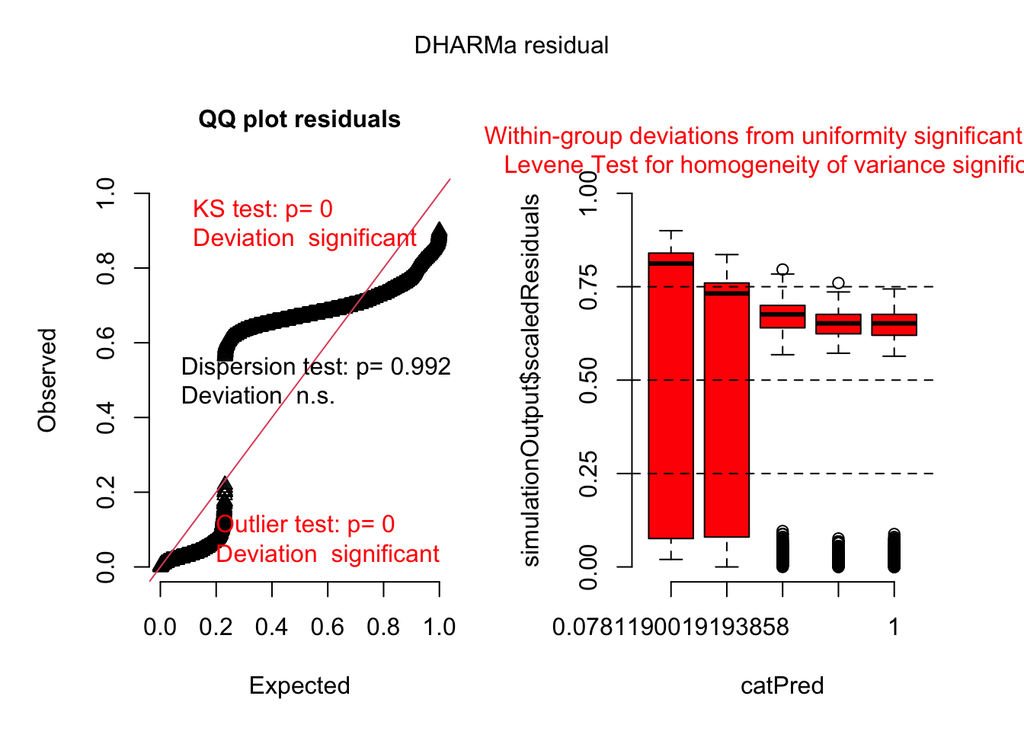

```r
plotG <- plot(simulationOutputG1)
```

```r
summary(modelBetaCat)
```

```
##  Family: beta  ( logit )
## Formula:          (purity_score - 1e-11) ~ as.factor(infilation)
## Data: MCLdata
##
##       AIC       BIC    logLik  deviance  df.resid
## -194644.1 -194603.8   97328.1 -194656.1      6076
##
##
## Dispersion parameter for beta family (): 1.28
##
## Conditional model:
##                          Estimate Std. Error z value Pr(>|z|)
## (Intercept)               2.94543    0.05256   56.04  < 2e-16 ***
## as.factor(infilation)1.4  0.18654    0.04752    3.93 8.65e-05 ***
## as.factor(infilation)2    0.27577    0.04517    6.10 1.03e-09 ***
## as.factor(infilation)2.5  0.31499    0.04430    7.11 1.15e-12 ***
## as.factor(infilation)3    0.31002    0.05207    5.95 2.63e-09 ***
## ---
## Signif. codes:  0 '***' 0.001 '**' 0.01 '*' 0.05 '.' 0.1 ' ' 1
```

```r
# Calculating the confidence intervals for the coefficients the Beta
confint(modelBetaCat)
```

```
##                               2.5 %    97.5 %  Estimate
## (Intercept)              2.84242198 3.0484432 2.9454326
## as.factor(infilation)1.4 0.09340384 0.2796780 0.1865409
## as.factor(infilation)2   0.18722986 0.3643014 0.2757656
## as.factor(infilation)2.5 0.22817741 0.4018118 0.3149946
## as.factor(infilation)3   0.20795805 0.4120849 0.3100215
```

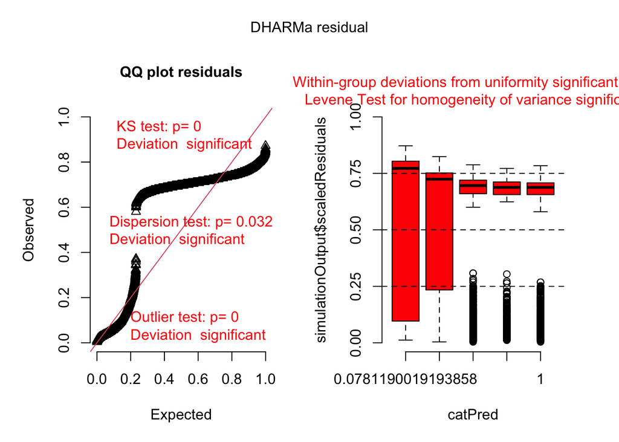

```r
#  Simulated the residuals from the beta
simulationOutputBCat<-simulateResiduals(fittedModel = modelBetaCat)
# A diagnostic plot of the simulated residuals
plot(simulationOutputBCat)
```

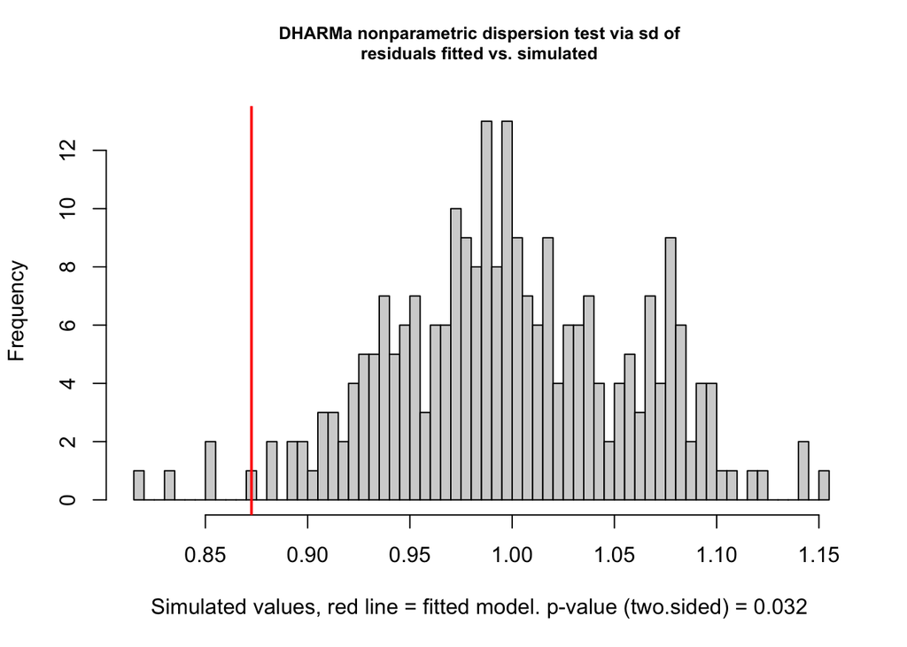

```
##
##  DHARMa nonparametric dispersion test via sd of residuals fitted vs.
##  simulated
##
## data:  simulationOutput
## dispersion = 0.87347, p-value = 0.032
## alternative hypothesis: two.sided
```

```r
#This line conducts a test for overdispersion or underdispersion
testDispersion(modelBetaCat)
```

```r
#mixed broom package glms factor plotting catagorical means and confidence intervals
modelBetaCat0 <- glmmTMB((purity_score-0.00000000001) ~ 0+as.factor(infilation),
                 family = beta_family(link = "logit"),
                 data = MCLdata)
# Output summaries of the model
summary(modelBetaCat0)
```

```
##  Family: beta  ( logit )
## Formula:          (purity_score - 1e-11) ~ 0 + as.factor(infilation)
## Data: MCLdata
##
##       AIC       BIC    logLik  deviance  df.resid
## -194644.1 -194603.8   97328.1 -194656.1      6076
##
##
## Dispersion parameter for beta family (): 1.28
##
## Conditional model:
##                          Estimate Std. Error z value Pr(>|z|)
## as.factor(infilation)1.2  2.94540    0.05256   56.04   <2e-16 ***
## as.factor(infilation)1.4  3.13196    0.04853   64.54   <2e-16 ***
## as.factor(infilation)2    3.22117    0.04636   69.48   <2e-16 ***
## as.factor(infilation)2.5  3.26041    0.04556   71.57   <2e-16 ***
## as.factor(infilation)3    3.25545    0.05315   61.25   <2e-16 ***
## ---
## Signif. codes:  0 '***' 0.001 '**' 0.01 '*' 0.05 '.' 0.1 ' ' 1
```

```r
Anova(modelBetaCat0)
```

```
## Analysis of Deviance Table (Type II Wald chisquare tests)
##
## Response: (purity_score - 1e-11)
##                        Chisq Df Pr(>Chisq)
## as.factor(infilation) 6269.9  5  < 2.2e-16 ***
## ---
## Signif. codes:  0 '***' 0.001 '**' 0.01 '*' 0.05 '.' 0.1 ' ' 1
```

```r
# The fixed effects coefficients from the fitted model object
fixef(modelBetaCat0)
```

```
##
## Conditional model:
## as.factor(infilation)1.2  as.factor(infilation)1.4    as.factor(infilation)2
##                    2.945                     3.132                     3.221
## as.factor(infilation)2.5    as.factor(infilation)3
##                    3.260                     3.255
```

```r
# The confidence intervals for the fixed effects
plogis(confint(modelBetaCat0))
```

```
##                              2.5 %    97.5 %  Estimate
## as.factor(infilation)1.2 0.9449241 0.9547140 0.9500458
## as.factor(infilation)1.4 0.9542116 0.9618403 0.9581921
## as.factor(infilation)2   0.9581258 0.9648393 0.9616232
## as.factor(infilation)2.5 0.9597326 0.9660950 0.9630452
## as.factor(infilation)3   0.9589593 0.9664184 0.9628685
```

```r
#Puts the data in the tidy format
tidy(modelBetaCat0, conf.int=T)
```

```
## # A tibble: 5 × 9
##   effect component term  estimate std.error statistic p.value conf.low conf.high
##   <chr>  <chr>     <chr>    <dbl>     <dbl>     <dbl>   <dbl>    <dbl>     <dbl>
## 1 fixed  cond      as.f…     2.95    0.0526      56.0       0     2.84      3.05
## 2 fixed  cond      as.f…     3.13    0.0485      64.5       0     3.04      3.23
## 3 fixed  cond      as.f…     3.22    0.0464      69.5       0     3.13      3.31
## 4 fixed  cond      as.f…     3.26    0.0456      71.6       0     3.17      3.35
## 5 fixed  cond      as.f…     3.26    0.0531      61.3       0     3.15      3.36
```

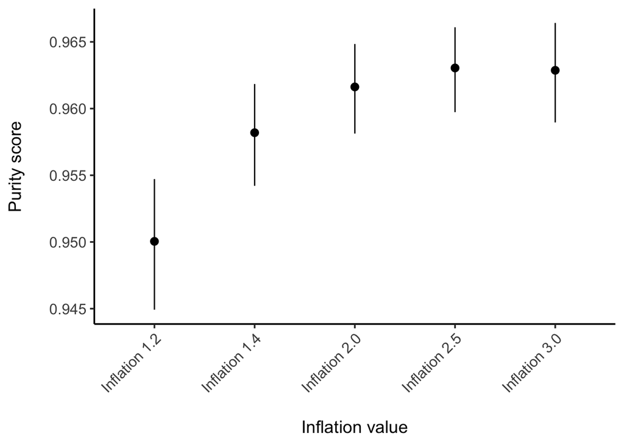

```r
#Get the confidence intervals for the beta
modcoef2 <- tidy(modelBetaCat0, conf.int = TRUE)


# Transform the coefficients, conf.low, and conf.high using the inverse logit function
modcoef2$estimate_transformed <- exp(modcoef2$estimate) / (1 + exp(modcoef2$estimate))
modcoef2$conf.low_transformed <- exp(modcoef2$conf.low) / (1 + exp(modcoef2$conf.low))
modcoef2$conf.high_transformed <- exp(modcoef2$conf.high) / (1 + exp(modcoef2$conf.high))

#Final plot that shows the estimated coefficients and their confidence intervals for different levels of the infilation variable in the beta regression model
finalPlot <- ggplot(modcoef2, aes(term, estimate_transformed)) +
geom_point() +
geom_pointrange(aes(ymin = conf.low_transformed, ymax = conf.high_transformed)) +
labs(x = "Inflation value", y = "Purity score") +
scale_x_discrete(labels = c("as.factor(infilation)1.2" = "Inflation 1.2",
"as.factor(infilation)1.4" = "Inflation 1.4",
"as.factor(infilation)2" = "Inflation 2.0",
"as.factor(infilation)2.5" = "Inflation 2.5",
"as.factor(infilation)3" = "Inflation 3.0")) +
theme_classic(base_size = 14) +
theme(axis.text.x = element_text(angle = 45, hjust = 1, size = 12), # Adjusted axis label font size
axis.title.x = element_text(margin = margin(t = 20), size = 14), # Adjusted x-axis title font size
axis.text.y = element_text(size = 12), # Adjusted axis label font size
axis.title.y = element_text(margin = margin(r = 20), size = 14))

finalPlot
```

```r
#Save the final plot
ggsave("finalPlot2.png", finalPlot, width = 10, height = 8, dpi = 300)
```

```r
model_summary <- summary(modelBetaCat0)

model_summary
```

```
##  Family: beta  ( logit )
## Formula:          (purity_score - 1e-11) ~ 0 + as.factor(infilation)
## Data: MCLdata
##
##       AIC       BIC    logLik  deviance  df.resid
## -194644.1 -194603.8   97328.1 -194656.1      6076
##
##
## Dispersion parameter for beta family (): 1.28
##
## Conditional model:
##                          Estimate Std. Error z value Pr(>|z|)
## as.factor(infilation)1.2  2.94540    0.05256   56.04   <2e-16 ***
## as.factor(infilation)1.4  3.13196    0.04853   64.54   <2e-16 ***
## as.factor(infilation)2    3.22117    0.04636   69.48   <2e-16 ***
## as.factor(infilation)2.5  3.26041    0.04556   71.57   <2e-16 ***
## as.factor(infilation)3    3.25545    0.05315   61.25   <2e-16 ***
## ---
## Signif. codes:  0 '***' 0.001 '**' 0.01 '*' 0.05 '.' 0.1 ' ' 1
```

```r
Anova(modelBetaCat0)
```

```
## Analysis of Deviance Table (Type II Wald chisquare tests)
##
## Response: (purity_score - 1e-11)
##                        Chisq Df Pr(>Chisq)
## as.factor(infilation) 6269.9  5  < 2.2e-16 ***
## ---
## Signif. codes:  0 '***' 0.001 '**' 0.01 '*' 0.05 '.' 0.1 ' ' 1
```

```r
coefficients <- model_summary$coefficients$cond

# Applied the inverse logit transformation to the coefficients
transformed_coefficients <- plogis(coefficients[, "Estimate"])

# Created a data frame with the transformed coefficients
transformed_df <- data.frame(
  term = rownames(coefficients),
  estimate_transformed = transformed_coefficients
)

print(transformed_df)
```

```
##                                              term estimate_transformed
## as.factor(infilation)1.2 as.factor(infilation)1.2            0.9500458
## as.factor(infilation)1.4 as.factor(infilation)1.4            0.9581921
## as.factor(infilation)2     as.factor(infilation)2            0.9616232
## as.factor(infilation)2.5 as.factor(infilation)2.5            0.9630452
## as.factor(infilation)3     as.factor(infilation)3            0.9628685
```

```r
# The marginal means for the infilation factor
emmeans_inf <- emmeans(modelBetaCat0, "infilation")

# Pairwise comparisons using Bonferroni correction
pairs_inf <- pairs(emmeans_inf, adjust = "bonferroni")


print(pairs_inf)
```

```
##  contrast                      estimate     SE  df z.ratio p.value
##  infilation1.2 - infilation1.4 -0.18656 0.0475 Inf  -3.926  0.0009
##  infilation1.2 - infilation2   -0.27577 0.0452 Inf  -6.105  <.0001
##  infilation1.2 - infilation2.5 -0.31500 0.0443 Inf  -7.111  <.0001
##  infilation1.2 - infilation3   -0.31005 0.0521 Inf  -5.954  <.0001
##  infilation1.4 - infilation2   -0.08921 0.0400 Inf  -2.228  0.2587
##  infilation1.4 - infilation2.5 -0.12844 0.0390 Inf  -3.290  0.0100
##  infilation1.4 - infilation3   -0.12349 0.0477 Inf  -2.590  0.0961
##  infilation2 - infilation2.5   -0.03924 0.0361 Inf  -1.085  1.0000
##  infilation2 - infilation3     -0.03428 0.0453 Inf  -0.756  1.0000
##  infilation2.5 - infilation3    0.00495 0.0445 Inf   0.111  1.0000
##
## Results are given on the log odds ratio (not the response) scale.
## P value adjustment: bonferroni method for 10 tests
```

Final reflections (10 pts): Address the following questions in numbered format 1. Rank your visualizations from 1-5 (or more) in the order in which you would like them to be evaluated I will rank them based on how they are labeled in the StoryMap Figure 13 Figure 4 Figure 5 Figure 9 2. Which visualizations, if any, were you most pleased with creating and Why? I was most pleased with creating Figure 13 because the process of getting there was the most challenging, since I had to back transform the data and figure out I needed to use the mixed broom package. I am also pleased with how the density plot looks (Figure 4) and the dotted line that shows the average density. 3. Did you have any issues accessing the data for your project? How did you resolve these? Thankfully my lab has a great API for all the data so getting it was easy. 4. How did your project topic evolve from what you first envisioned, and Why? At first I wanted to include nucleotide sequence similarity based on BLAST hits but I essentially ran out of time getting that data together. I also learned about the MCL clustering algorithm and wanted to see if there was a statistical way to analyze which inflation value I should use. 5. Did you have issues related to any analyses that you performed, the timeline of the project, your computer or other tools necessary, etc? How did you resolve or workaround these issues? I definitely ran into some trouble analyzing the data because I really struggle with the statistics. I haven’t had stats since a 4 week summer course during 2020, so I came into this class with basically no knowledge which was frustrating. As I got help from Dr. Brown and kept trying different things through trial and error. I learned a lot and was able to perform the analysis.  
6. If you had more time, what would you change (e.g., things you might add or remove)? I believe I would change the overall research question. I don’t think this was the best way to analyze this type of clustering algorithm. What I wish I could have done is compare the clustering algorithm to lab determine operons so that I could run a statistical analysis of which inflation value was more accurate at clustering the genes when compared to laboratory ones. Comparing the MCL algorithm to itself was a bit confusing which made the statistical analysis less clear to me. 7. Are you happy with the final results of your project? I am pleased with the final results despite the statistical models not being a very good fit to the data. I am excited I was able to cluster the genes and technically answer my research question of which inflation clusters groups of genes that have similar functions together more often. I also learned a lot about statistics through this process which was rewarding. 8. May I use your project and/or visualizations as an example for later classes? If so, would you like me to redact your name? You are welcome to share the project and you don’t have to redact my name. 9. What advice would you give to future students taking this course? The advice I would give students in this course is to really try to brush up on statistics before taking the course, because understanding the statistics will help you visualize your data better. I would also tell them to be patient with themselves and that it is a learning process and you don’t have to understand everything instantly. Reach out for help when you need it from either Dr. Brown or others in your class, statistics is more fun when you talk through problems together.